# Arba Minch practical session

Julien Arino

2023-12-20

Note: just before the pandemic, I published a paper on “being data aware” in mathematical epidemiology. You can find it here. I also put a copy on the GitHub repo. Note that you should really look at the code of that paper, which has its [own repository](https://github.com/julien-arino/modelling-with-data), as the publisher did a very bad job of rendering the file.

## Getting some data online

You can get some WHO data about Ethiopia from [here](https://data.who.int/countries/231), which will point you back [here](https://www.who.int/data/gho/data/themes/mortality-and-global-health-estimates/ghe-leading-causes-of-death) for leading causes of death.

Let us see, however, if we can get the data directly from R. Two libraries may prove useful: `WHO` (but this was “removed for policy violation”, so who knows) and `wbstats`, which gets data from the World Bank.

### WHO data sets

| x |
| --- |
| Infant mortality rate (between birth and 11 months per 1000 live births) |
| Adolescent birth rate (per 1000 women) |
| Contraceptive prevalence (%) |
| Under-five mortality rate (per 1000 live births) (SDG 3.2.1) |
| Median availability of selected generic medicines (%) - Public |
| Median consumer price ratio of selected generic medicines - Public |
| Children aged <5 years sleeping under insecticide-treated nets (%) |
| Children aged <5 years with fever who received treatment with any antimalarial (%) |
| Prevalence of condom use by adults during higher-risk sex (15-49) (%) |
| Deaths due to malaria (per 100 000 population) (see MALARIA_EST_MORTALITY) ( void MDG_0000000016) |
| Deaths due to tuberculosis among HIV-negative people (per 100 000 population) |
| Deaths due to tuberculosis among HIV-positive people (per 100 000 population) |
| Prevalence of HIV among adults aged >=15 years (per 100 000 population) |
| Incidence of tuberculosis (per 100 000 population per year) |
| Population aged 15-24 years with comprehensive correct knowledge of HIV/AIDS (%) |
| Tuberculosis detection rate under DOTS (%) |
| Prevalence of tuberculosis (per 100 000 population) |
| Tuberculosis treatment success under DOTS (%) |
| Births attended by skilled health personnel (%) |
| Maternal mortality ratio (per 100 000 live births) |
| xxxxx for deletion: (child stunting, see NUTSTUNTINGPREV) |
| nMx - age-specific death rate between ages x and x+n |
| nqx - probability of dying between ages x and x+n |
| lx - number of people left alive at age x |
| ndx - number of people dying between ages x and x+n |
| nLx - person-years lived between ages x and x+n |
| Tx - person-years lived above age x |
| ex - expectation of life at age x |
| Number of deaths (see MORT_100) |
| GBD - crude death rate |

[output cut: 2214 more lines]

### World Bank data sets

| x |
| --- |
| The poverty headcount index measures the proportion of the population with daily per capita income (in 2011 PPP) below the poverty line. |
| The poverty headcount index measures the proportion of the population with daily per capita income (in 2005 PPP) below the poverty line. |
| The poverty headcount index measures the proportion of the population with daily per capita income (in 2005 PPP) below the poverty line. |
| The poverty headcount index measures the proportion of the population with daily per capita income below the official poverty line developed by each country. |
| The poverty headcount index measures the proportion of the population with daily per capita income (in 2005 PPP) below the poverty line. |
| The poverty headcount index measures the proportion of the population with daily per capita income (in 2005 PPP) below the poverty line. |
| The poverty gap captures the mean aggregate income or consumption shortfall relative to the poverty line across the entire population. It measures the total resources needed to bring all the poor to t… |
| The poverty gap captures the mean aggregate income or consumption shortfall relative to the poverty line across the entire population. It measures the total resources needed to bring all the poor to t… |
| The poverty gap captures the mean aggregate income or consumption shortfall relative to the poverty line across the entire population. It measures the total resources needed to bring all the poor to t… |
| The poverty severity index combines information on both poverty and inequality among the poor by averaging the squares of the poverty gaps relative the poverty line |
| The poverty severity index combines information on both poverty and inequality among the poor by averaging the squares of the poverty gaps relative the poverty line |
| The poverty severity index combines information on both poverty and inequality among the poor by averaging the squares of the poverty gaps relative the poverty line |
| The poverty headcount index measures the proportion of the population with daily per capita income (in 2011 PPP) below the poverty line. |
| The poverty headcount index measures the proportion of the population with daily per capita income (in 2005 PPP) below the poverty line. |
| The poverty headcount index measures the proportion of the population with daily per capita income (in 2005 PPP) below the poverty line. |
| The poverty headcount index measures the proportion of the population with daily per capita income below the official poverty line developed by each country. |
| The poverty headcount index measures the proportion of the population with daily per capita income (in 2005 PPP) below the poverty line. |
| The poverty headcount index measures the proportion of the population with daily per capita income (in 2005 PPP) below the poverty line. |
| The poverty gap captures the mean aggregate income or consumption shortfall relative to the poverty line across the entire population. It measures the total resources needed to bring all the poor to t… |
| The poverty gap captures the mean aggregate income or consumption shortfall relative to the poverty line across the entire population. It measures the total resources needed to bring all the poor to t… |

### We need to find the right data set

Those data sets are huge: there are 3145 data sets in the WHO data, and 23722 in the World Bank data. We need to find the right one. Let us look for example for the word “mortality” in both data sets and see what we get.

Display the indices we found. First, from WHO

| x |
| --- |
| Infant mortality rate (between birth and 11 months per 1000 live births) |
| Under-five mortality rate (per 1000 live births) (SDG 3.2.1) |
| Deaths due to malaria (per 100 000 population) (see MALARIA_EST_MORTALITY) ( void MDG_0000000016) |
| Maternal mortality ratio (per 100 000 live births) |
| Neonatal mortality rate (0 to 27 days) per 1000 live births) (SDG 3.2.2) |
| Adult mortality rate (probability of dying between 15 and 60 years per 1000 population) |
| Age-standardized NCD mortality rate (per 100 000 population) |
| Deaths due to malaria (per 100 000 population) (see MALARIA_EST_MORTALITY) ( void WHS2_152) |
| Age-standardized mortality rate by cause (per 100 000 population) - Cancer |
| Age-standardized mortality rate by cause (per 100 000 population) - Cardiovascular |
| Maternal mortality ratio (per 100 000 live births) - Country reported estimates |
| Alcohol-related injury mortality, per 1,000 |
| Alcohol-related disease mortality, per 100,000 (15+ years) |
| Number of national population surveys - child mortality |
| Number of national population surveys - maternal mortality |
| Infant mortality rate (deaths per 1000 live births) |
| Neonatal mortality rate (deaths per 1000 live births) |
| Under-five mortality rate (deaths per 1000 live births) |
| Under 5 Mortality |
| Infant mortality |
| NCD mortality rate |
| CVD and Diabetes mortality rate |
| Cancer mortality rate |
| TB mortality rate |
| Malaria mortality rate |
| HIV mortality rate |
| Years of life lost from mortality (YLLs) |
| Years of life lost from mortality (YLLs) (per 100 000 population) |
| Mortality rate attributed to unintentional poisoning (per 100 000 population) |
| Age-standardized road traffic mortality (per 100 000 population) |

[output cut: 174 more lines]

Then World Bank

| x |
| --- |
| This indicator presents the mortality rate attributable to household air pollution as a factor of deaths per 100 000 population. Data is taken from the United Nations Sustainable Goals, representing I… |
| This indicator presents the mortality rate attributable to ambient air pollution as a factor of deaths per 100 000 population. Data is taken from the United Nations Sustainable Goals, representing Ind… |
| This indicator is a derived from the following indicators: - (a) Business impact of malaria (b) Malaria incidence (c) Business impact of tuberculosis (d) Tuberculosis incidence (e) Business impact of … |
| Adult Survival Rate is calculated by subtracting the mortality rate for 15-60 year-olds from 1. Most recent estimates are used. Year of most recent estimate shown in data notes. |
| Adult Survival Rate is calculated by subtracting the mortality rate for 15-60 year-olds from 1. Most recent estimates are used. Year of most recent estimate shown in data notes. |
| Adult Survival Rate is calculated by subtracting the mortality rate for 15-60 year-olds from 1. Most recent estimates are used. Year of most recent estimate shown in data notes. |
| Probability of Survival to Age 5 is calculated by subtracting the under-5 mortality rate from 1. Most recent estimates are used. Year of most recent estimate shown in data notes. |
| Probability of Survival to Age 5 is calculated by subtracting the under-5 mortality rate from 1. Most recent estimates are used. Year of most recent estimate shown in data notes. |
| Probability of Survival to Age 5 is calculated by subtracting the under-5 mortality rate from 1. Most recent estimates are used. Year of most recent estimate shown in data notes. |
| Deaths of children before their 1st birthday per 1,000 live births. Sample: children born up to 5 years before the survey for full population mortality estimates, and up to 10 years before the survey … |
| Deaths of children before their 1st birthday per 1,000 live births. Sample: children born up to 5 years before the survey for full population mortality estimates, and up to 10 years before the survey … |
| Deaths of children before their 1st birthday per 1,000 live births. Sample: children born up to 5 years before the survey for full population mortality estimates, and up to 10 years before the survey … |
| Deaths of children before their 1st birthday per 1,000 live births. Sample: children born up to 5 years before the survey for full population mortality estimates, and up to 10 years before the survey … |
| Deaths of children before their 1st birthday per 1,000 live births. Sample: children born up to 5 years before the survey for full population mortality estimates, and up to 10 years before the survey … |
| Deaths of children before their 1st birthday per 1,000 live births. Sample: children born up to 5 years before the survey for full population mortality estimates, and up to 10 years before the survey … |
| Deaths of children before their 5th birthday per 1,000 live births. Sample: children born up to 5 years before the survey for full population mortality estimates, and up to 10 years before the survey … |
| Deaths of children before their 5th birthday per 1,000 live births. Sample: children born up to 5 years before the survey for full population mortality estimates, and up to 10 years before the survey … |
| Deaths of children before their 5th birthday per 1,000 live births. Sample: children born up to 5 years before the survey for full population mortality estimates, and up to 10 years before the survey … |
| Deaths of children before their 5th birthday per 1,000 live births. Sample: children born up to 5 years before the survey for full population mortality estimates, and up to 10 years before the survey … |
| Deaths of children before their 5th birthday per 1,000 live births. Sample: children born up to 5 years before the survey for full population mortality estimates, and up to 10 years before the survey … |
| Deaths of children before their 5th birthday per 1,000 live births. Sample: children born up to 5 years before the survey for full population mortality estimates, and up to 10 years before the survey … |
| Infant Mortality Rate (IMR) per 1000: Infant mortality rate (IMR) is the number of deaths of children less than one year of age per 1000 live births. The rate for a given region is the number of child… |
| Under 5 Mortality Rate per 1000 is the number of deaths of children less than five years of age per 1000 live births. The rate for a given region is the number of children dying under five years of ag… |
| Health and Welfare: Within this sub-category the Ibrahim Index measures: (i) Incidence of TB – incidence of new cases of Tuberculosis. (ii) Child Mortality – likelihood that a newborn baby will die be… |
| Particulate emissions damage is the damage due to exposure of a country’s population to ambient concentrations of particulates measuring less than 2.5 microns in diameter (PM2.5), ambient ozone pollut… |
| Particulate emissions damage is the damage due to exposure of a country’s population to ambient concentrations of particulates measuring less than 2.5 microns in diameter (PM2.5), ambient ozone pollut… |
| Share of the population of the stated age group that has completed primary education or incomplete lower secondary education as the highest level of educational attainment. Projections are based on co… |
| Share of the population of the stated age group that has completed primary education or incomplete lower secondary education as the highest level of educational attainment. Projections are based on co… |
| Share of the population of the stated age group that has completed primary education or incomplete lower secondary education as the highest level of educational attainment. Projections are based on co… |
| Share of the population of the stated age group that has completed lower secondary or incomplete upper secondary education as the highest level of educational attainment. Projections are based on coll… |

[output cut: 459 more lines]

You see the idea… Most of the epidemiologicalm data in WB comes from WHO and we could just skip the WB data but from the experience on 2023-12-20, we had better use that data set.

Display the indices we found.

| indicator_id | indicator | unit | indicator_desc | source_org | topics | source_id | source |
| --- | --- | --- | --- | --- | --- | --- | --- |
| DT.ODA.DACD.HLTH.BAS.CD | Gross ODA aid disbursement for basic health, DAC donors total (current US$) | NA | This is described as basic health care; basic health infrastructure; basic nutrition; infectious disease control; health education; malaria control; tuberculosis control and health personnel developme… | Development Assistance Committee of the Organisation for Economic Co-operation and Development, Geographical Distribution of Financial Flows to Developing Countries, Development Co-operation Report, a… | NULL | 11 | Africa Development Indicators |
| GCI.4THPILLAR.XQ | 4th pllar: Health and primary education | NA | This indicator is a derived from the following indicators: - (a) Business impact of malaria (b) Malaria incidence (c) Business impact of tuberculosis (d) Tuberculosis incidence (e) Business impact of … | The Global Competitiveness Report: various issues (http://gcr.weforum.org/). | NULL | 11 | Africa Development Indicators |
| IQ.CPA.HRES.XQ | CPIA building human resources rating (1=low to 6=high) | NA | Building human resources assesses the national policies and public and private sector service delivery that affect the access to and quality of health and education services, including prevention and … | World Bank Group, CPIA database (http://www.worldbank.org/ida). | 13 , Public Sector | 2 | World Development Indicators |
| MO.INDEX.HDEV.XQ | Human Development | NA | Health and Welfare: Within this sub-category the Ibrahim Index measures: (i) Incidence of TB – incidence of new cases of Tuberculosis. (ii) Child Mortality – likelihood that a newborn baby will die be… | Mo Ibrahim Foundation, electronic files and web site. | NULL | 11 | Africa Development Indicators |
| SH.TBS.CURE.ZS | Tuberculosis treatment success rate (% of new cases) | NA | Tuberculosis treatment success rate is the percentage of all new tuberculosis cases (or new and relapse cases for some countries) registered under a national tuberculosis control programme in a given … | World Health Organization, Global Tuberculosis Report. | 8 , Health | 2 | World Development Indicators |
| SH.TBS.DTEC.ZS | Tuberculosis case detection rate (%, all forms) | NA | Tuberculosis case detection rate (all forms) is the number of new and relapse tuberculosis cases notified to WHO in a given year, divided by WHO’s estimate of the number of incident tuberculosis cases… | World Health Organization, Global Tuberculosis Report. | 8 , Health | 2 | World Development Indicators |
| SH.TBS.INCD | Incidence of tuberculosis (per 100,000 people) | NA | Incidence of tuberculosis is the estimated number of new and relapse tuberculosis cases arising in a given year, expressed as the rate per 100,000 population. All forms of TB are included, including c… | World Health Organization, Global Tuberculosis Report. | 8 , 2 , Health , Aid Effectiveness | 2 | World Development Indicators |
| SH.TBS.INCD.HG | Incidence of tuberculosis, high uncertainty bound (per 100,000 people) | NA | Incidence of tuberculosis is the estimated number of new pulmonary, smear positive, and extra-pulmonary tuberculosis cases. | World Health Organization, Global Tuberculosis Control Report. | NULL | 11 | Africa Development Indicators |
| SH.TBS.INCD.LW | Incidence of tuberculosis, low uncertainty bound (per 100,000 people) | NA | Incidence of tuberculosis is the estimated number of new pulmonary, smear positive, and extra-pulmonary tuberculosis cases. | World Health Organization, Global Tuberculosis Control Report. | NULL | 11 | Africa Development Indicators |
| SH.TBS.MORT | Tuberculosis death rate (per 100,000 people) | NA | Tuberculosis death rate is the estimated number of deaths from tuberculosis among HIV-negative people, expressed as the rate per 100,000 population. Estimates for all years are recalculated as new inf… | World Health Organization, Global Tuberculosis Report. | NULL | 16 | Health Nutrition and Population Statistics |
| SH.TBS.MORT.HG | Deaths due to tuberculosis among HIV-negative people, high uncertainty bound (per 100,000 population) | NA | The estimated number of deaths attributable to tuberculosis (TB) in a given time period. | World Health Organization, Global Tuberculosis Control Report. | NULL | 11 | Africa Development Indicators |
| SH.TBS.MORT.LW | Deaths due to tuberculosis among HIV-negative people, low uncertainty bound (per 100,000 population) | NA | The estimated number of deaths attributable to tuberculosis (TB) in a given time period. | World Health Organization, Global Tuberculosis Control Report. | NULL | 11 | Africa Development Indicators |
| SH.TBS.PREV | Tuberculosis prevalence rate (per 1000,000 population, WHO) | NA | The number of cases of tuberculosis (all forms) in a population at a given point in time (the middle of the calendar year), expressed as the rate per 100 000 population. It is sometimes referred to as… | World Health Organization, Global Tuberculosis Control Report. | NULL | 11 | Africa Development Indicators |
| SH.TBS.PREV.HG | Tuberculosis prevalence rate, high uncertainty bound (per 1000,000 population, WHO) | NA | The number of cases of tuberculosis (all forms) in a population at a given point in time (the middle of the calendar year), expressed as the rate per 100 000 population. It is sometimes referred to as… | World Health Organization, Global Tuberculosis Control Report. | NULL | 11 | Africa Development Indicators |
| SH.TBS.PREV.LW | Tuberculosis prevalence rate, low uncertainty bound (per 1000,000 population, WHO) | NA | The number of cases of tuberculosis (all forms) in a population at a given point in time (the middle of the calendar year), expressed as the rate per 100 000 population. It is sometimes referred to as… | World Health Organization, Global Tuberculosis Control Report. | NULL | 11 | Africa Development Indicators |

In the end, we have the following data set.

| date | incidence | mortality | prevalence | cure | detection |
| --- | --- | --- | --- | --- | --- |
| 2000 | 421 | 85 | 430 | 80 | 32 |
| 2001 | 409 | 86 | 409 | 76 | 34 |
| 2002 | 393 | 80 | 391 | 76 | 39 |
| 2003 | 376 | 75 | 369 | 70 | 43 |
| 2004 | 358 | 69 | 350 | 79 | 46 |
| 2005 | 341 | 64 | 333 | 78 | 47 |
| 2006 | 325 | 60 | 314 | 84 | 47 |
| 2007 | 310 | 54 | 296 | 84 | 51 |
| 2008 | 296 | 46 | 280 | 80 | 56 |
| 2009 | 282 | 41 | 265 | 81 | 61 |
| 2010 | 268 | 36 | 251 | 77 | 65 |
| 2011 | 253 | 33 | 237 | 89 | 67 |
| 2012 | 239 | 36 | NA | 91 | 64 |
| 2013 | 224 | 37 | NA | 89 | 61 |
| 2014 | 207 | 36 | NA | 89 | 58 |
| 2015 | 192 | 26 | NA | 84 | 69 |
| 2016 | 177 | 26 | NA | 90 | 67 |
| 2017 | 164 | 25 | NA | 96 | 66 |
| 2018 | 151 | 22 | NA | 88 | 68 |
| 2019 | 140 | 19 | NA | 90 | 70 |
| 2020 | 129 | 17 | NA | 86 | 72 |
| 2021 | 119 | 16 | NA | 87 | 73 |
| 2022 | 126 | 17 | NA | NA | 73 |

# The model

We settled on a model, which I am modifying a bit to make it more like the one of Castillo-Chavez and Feng.

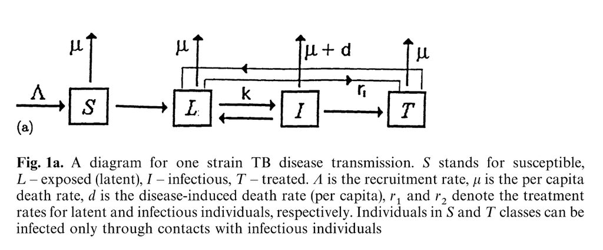

$$\begin{aligned}
S' &= b-dS-\beta_SS\frac{I}{N} \\
L' &= \beta_SS\frac{I}{N}
+\beta_TT\frac{I}{N}
-(d+\varepsilon+t_L)L \\
I' &= \varepsilon L-(d+\delta+t_I)I \\
T' &= t_LL+t_II-\beta_TT\frac IN-dT
\end{aligned}$$

where $S$ is the number of susceptible individuals, $L$ the number of latently infected individuals, $I$ the number of actively infected individuals and $T$ the number of treated individuals.

## Computation of $\mathcal{R}_0$

Set $L=I=T=0$ and solve for $S$, giving that at the DFE, $S^\star=b/d$. We find that
$$F=\begin{pmatrix}
0 & \beta_S & 0 \\
0 & 0 & 0 \\
0 & 0 & 0
\end{pmatrix}$$
and
$$V = \begin{pmatrix}
d+\varepsilon+t_L & 0 & 0 \\
-\varepsilon & d+\delta+t_I & 0 \\
-t_L & -t_I & d
\end{pmatrix}$$
Given the shape of $F$ and $V$, we realise that the only information we need about $V^{-1}$ is the value of the (2,1) entry, which equals
$$\frac{\varepsilon}
{(t_I+\delta+d)(t_L+\varepsilon+d)}$$
and thus
$$\mathcal{R}_0 = \frac{\varepsilon\beta_S}
{(t_I+\delta+d)(t_L+\varepsilon+d)}$$

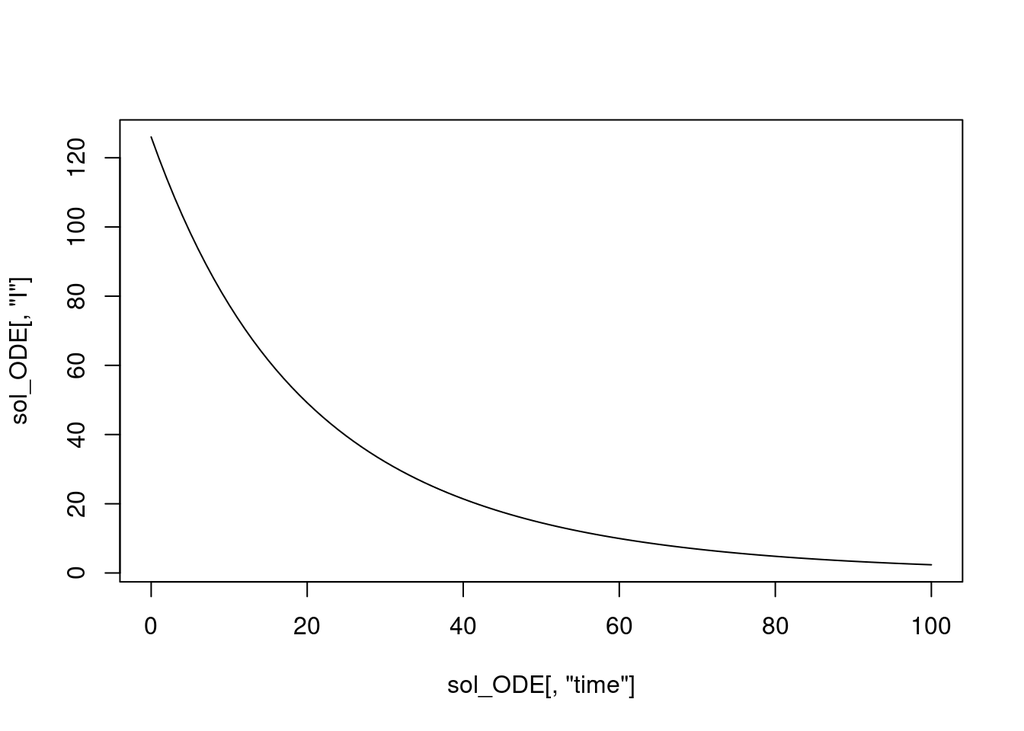

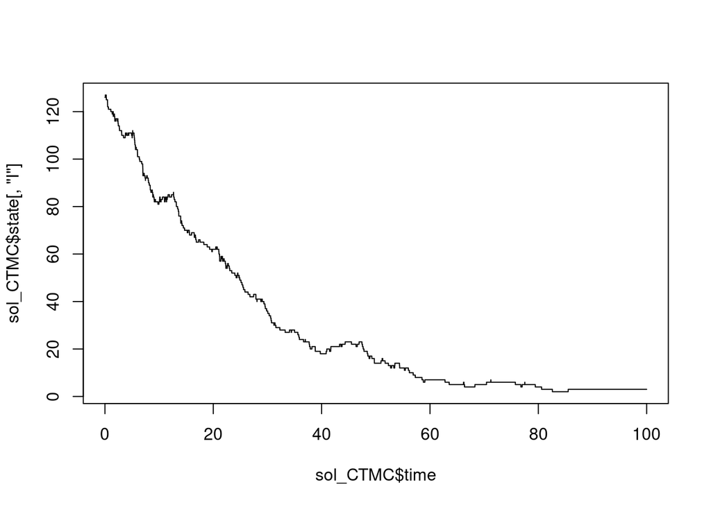

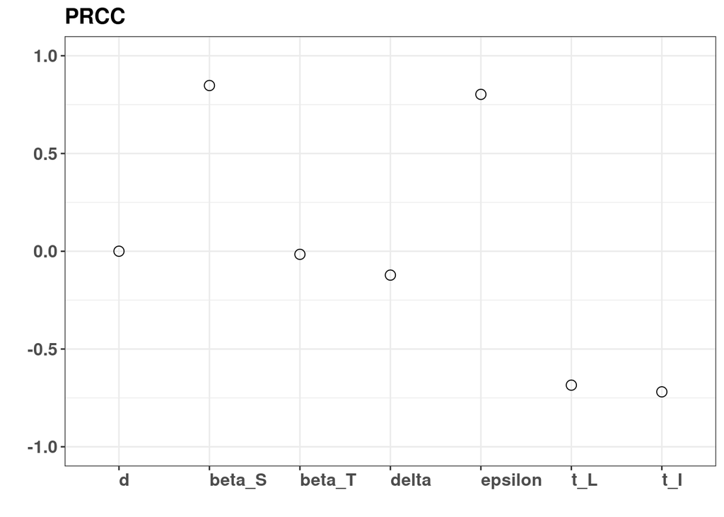